# 02_넘파이 배열

### 넘파이 배열 만드는 방법

- array() 함수를 이용한 다른 파이썬구조(예: 리스트, 튜플)로부터의 변환
- 넘파이 배열을 생성하는 함수 이용(예: arange, ones, zeros, 등.)
- 표준 형식 또는사용자 정의 형식으로 디스크에서 배열 읽기
- 문자열이나 버퍼를 사용하여 원시 바이트에서 배열 만들기
- 특수 라이브러리 함수(예: random) 이용

참고: https://docs.scipy.org/doc/numpy/index.html

### 1. array() 함수를 사용하여 리스트 또는 튜플로부터 넘파이 배열을 생성

```
numpy.array(object, dtype=None, copy=True)
```

```python
import numpy as np
```

```python
A = np.array([2,3,4])
A
```

```
array([2, 3, 4])
```

```python
A.dtype
```

```
dtype('int64')
```

```python
# 결과 배열의 유형은 리스트 또는 튜플의 요소 유형에서 추론됨
B = np.array([1.2, 3.5, 5.1])
B.dtype
```

```
dtype('float64')
```

```python
C = np.array([[1,2], [3,4]], dtype=complex)  # dtype=complex 은 복소수
C
```

```
array([[1.+0.j, 2.+0.j],
       [3.+0.j, 4.+0.j]])
```

```python
D = np.array(C, copy=False)
```

```python
# copy=False이고 dtype을 지정하지 않으면 새로운 배열의 복사본을 생성하지 않음(즉, 같은 값을 참조함)
id(C), id(D)
```

```
(132109756431216, 132109756431216)
```

```python
E = np.array(A, copy=True)  # copy=True 는 새로운 배열 생성
id(E), id(A)
```

```
(132109756810032, 132109770956720)
```

### 2. 기본값이 있는 배열 만들기

초기 특정 값으로 채워진 배열을 만드는 몇 가지 기능을 제공

- **empty()** : 초기 내용이 임의이고 메모리의 상태에 따라 달라지는 배열
- **zeros()** : 0으로 채워진 배열
- **ones()** : 1로 구성된 배열
- 배열의 dtype은 float64
- 원하면 dtype 속성으로 타입 지정 가능

```python
np.zeros((3,4))
```

```
array([[0., 0., 0., 0.],
       [0., 0., 0., 0.],
       [0., 0., 0., 0.]])
```

```python
np.ones((2,3,4), dtype=np.int16)  # 요소 하나의 크기가 2바이트로 메모리 공간을 줄일 수 있음
```

```
array([[[1, 1, 1, 1],
        [1, 1, 1, 1],
        [1, 1, 1, 1]],

       [[1, 1, 1, 1],
        [1, 1, 1, 1],
        [1, 1, 1, 1]]], dtype=int16)
```

```python
np.empty((2,3))  # 메모리 상태에 따라 달라짐
```

```
array([[4.93245350e-310, 0.00000000e+000, 6.52710007e-310],
       [3.17971080e+226, 0.00000000e+000, 0.00000000e+000]])
```

### 3. 연속된 값을 갖는 배열 만들기

- **arange()** : from부터 to까지(포함 안함) by씩 건너뛴 값 목록을 생성.

  ```
    numpy.arange([from, ]to, [by, ]dtype=None)
  ```

- **linspace()** : begin부터 end까지(포함) num개 목록을 생성

  ```
    numpy.linspace(begin, end, num=50)
  ```

```python
np.arange(10)
```

```
array([0, 1, 2, 3, 4, 5, 6, 7, 8, 9])
```

```python
np.arange(11,20)
```

```
array([11, 12, 13, 14, 15, 16, 17, 18, 19])
```

```python
np.arange(10, 30, 5)
```

```
array([10, 15, 20, 25])
```

```python
np.arange(0, 2, 0.3)
```

```
array([0. , 0.3, 0.6, 0.9, 1.2, 1.5, 1.8])
```

```python
np.linspace(0, 2)
```

```
array([0.        , 0.04081633, 0.08163265, 0.12244898, 0.16326531,
       0.20408163, 0.24489796, 0.28571429, 0.32653061, 0.36734694,
       0.40816327, 0.44897959, 0.48979592, 0.53061224, 0.57142857,
       0.6122449 , 0.65306122, 0.69387755, 0.73469388, 0.7755102 ,
       0.81632653, 0.85714286, 0.89795918, 0.93877551, 0.97959184,
       1.02040816, 1.06122449, 1.10204082, 1.14285714, 1.18367347,
       1.2244898 , 1.26530612, 1.30612245, 1.34693878, 1.3877551 ,
       1.42857143, 1.46938776, 1.51020408, 1.55102041, 1.59183673,
       1.63265306, 1.67346939, 1.71428571, 1.75510204, 1.79591837,
       1.83673469, 1.87755102, 1.91836735, 1.95918367, 2.        ])
```

```python
np.linspace(0, 2, 9)
```

```
array([0.  , 0.25, 0.5 , 0.75, 1.  , 1.25, 1.5 , 1.75, 2.  ])
```

```python
np.linspace(0, 10, 20)
```

```
array([ 0.        ,  0.52631579,  1.05263158,  1.57894737,  2.10526316,
        2.63157895,  3.15789474,  3.68421053,  4.21052632,  4.73684211,
        5.26315789,  5.78947368,  6.31578947,  6.84210526,  7.36842105,
        7.89473684,  8.42105263,  8.94736842,  9.47368421, 10.        ])
```

```python
# 많은 수의 점 데이터를 만들 때 유용
x = np.linspace(0, 2*np.pi, 100)
y = np.sin(x)  # 데이터 시각화하면 sin곡선
```

### 4. 배열의 차원 변경하기

배열은 각 축을 따라 요소 수만큼 주어진 차원을 가짐

- **ravel()** : 차원이 풀린 배열을 반환
- **reshape(6,2)** : shape가 수정된 배열을 반환, -1값을 사용할 수 있음
- **T** : 전치행렬(transposed-행렬의 행과 열을 뒤바꾼 행렬) 반환
- **resize()** : 현재 배열 객체를 바꿈, -1(음수)값을 사용할 수 없음
- **shape** : shape를 튜플형식으로 지정

```python
A = np.arange(12).reshape(3,4)
A
```

```
array([[ 0,  1,  2,  3],
       [ 4,  5,  6,  7],
       [ 8,  9, 10, 11]])
```

```python
A.shape
```

```
(3, 4)
```

```python
# 차원 변경
A.ravel()
```

```
array([ 0,  1,  2,  3,  4,  5,  6,  7,  8,  9, 10, 11])
```

```python
A.reshape(5,2)  # shape 지정시 요소의 갯수와 차원의 곱이 일치해야 함!!!
```

```
---------------------------------------------------------------------------
ValueError                                Traceback (most recent call last)
<ipython-input-23-2f3dd878eb4f> in <cell line: 1>()
----> 1 A.reshape(5,2)  # shape 지정시 요소의 갯수와 차원의 곱이 일치해야 함!!!

ValueError: cannot reshape array of size 12 into shape (5,2)
```

```python
A.reshape(6,2)
```

```
array([[ 0,  1],
       [ 2,  3],
       [ 4,  5],
       [ 6,  7],
       [ 8,  9],
       [10, 11]])
```

```python
A.T  # 전치행렬을 반환
```

```
array([[ 0,  4,  8],
       [ 1,  5,  9],
       [ 2,  6, 10],
       [ 3,  7, 11]])
```

```python
A.resize(2,6)  # reshape()는 현재 객체를 바꾸지 않고 변경된 객체 반환, resize()는 현재 객체를 바꿈
```

```python
A
```

```
array([[ 0,  1,  2,  3,  4,  5],
       [ 6,  7,  8,  9, 10, 11]])
```

```python
A.shape
```

```
(2, 6)
```

```python
# shape 속성에 값을 할당 => shape 변경
A.shape = (3,4)
```

```python
A
```

```
array([[ 0,  1,  2,  3],
       [ 4,  5,  6,  7],
       [ 8,  9, 10, 11]])
```

```python
A.reshape(2,-1)  # 차원을 하나만 지정하고 나머지는 알아서 자동 지정
```

```
array([[ 0,  1,  2,  3,  4,  5],
       [ 6,  7,  8,  9, 10, 11]])
```

```python
A.resize(4, -1)  # resize()는 자동 지정 안됨(음수 사용 불가) => error
```

```
---------------------------------------------------------------------------
ValueError                                Traceback (most recent call last)
<ipython-input-32-12653b963c0e> in <cell line: 1>()
----> 1 A.resize(4, -1)  # resize()는 자동 지정 안됨(음수 사용 불가) => error

ValueError: negative dimensions not allowed
```

### 5. 배열 인쇄

- 배열을 인쇄할 때 레이아웃
  - 마지막 축은 왼쪽에서 오른쪽으로 인쇄
  - 나머지는 위에서 아래로 인쇄
  - 각 슬라이스는 빈 줄로 구분
- 1차원 배열은 행, 2차원은 행렬, 3차원은 행렬 목록으로 인쇄
- reshape() 함수는 배열의 모양(shape)을 변경

```python
A = np.arange(6)
```

```python
print(A)  # print()함수는 중간에 , 가 보이지 않음
```

```
[0 1 2 3 4 5]
```

```python
A
```

```
array([0, 1, 2, 3, 4, 5])
```

```python
B = np.arange(12).reshape(4,3)
```

```python
print(B)
```

```
[[ 0  1  2]
 [ 3  4  5]
 [ 6  7  8]
 [ 9 10 11]]
```

```python
C = np.arange(24).reshape((2,3,4))  # (2,3,4)는 (3,4)모양의 배열이 2개 있음을 의미
```

```python
C
```

```
array([[[ 0,  1,  2,  3],
        [ 4,  5,  6,  7],
        [ 8,  9, 10, 11]],

       [[12, 13, 14, 15],
        [16, 17, 18, 19],
        [20, 21, 22, 23]]])
```

```python
print(np.arange(10000))
```

```
[   0    1    2 ... 9997 9998 9999]
```

```python
print(np.arange(10000).reshape(100, 100))
```

```
[[   0    1    2 ...   97   98   99]
 [ 100  101  102 ...  197  198  199]
 [ 200  201  202 ...  297  298  299]
 ...
 [9700 9701 9702 ... 9797 9798 9799]
 [9800 9801 9802 ... 9897 9898 9899]
 [9900 9901 9902 ... 9997 9998 9999]]
```

- 데이터 중간에 생략없이 전체 배열을 인쇄하려면 인쇄 옵션 변경

  ```
    numpy_set_printoptions(threshold=None)
  ```

```python
# threshold 속성 값이 배열의 데이터 수보다 크거나 같아야 됨
np.set_printoptions(threshold=10000)
```

```python
print(np.arange(100).reshape(10,10))
```

```
[[ 0  1  2  3  4  5  6  7  8  9]
 [10 11 12 13 14 15 16 17 18 19]
 [20 21 22 23 24 25 26 27 28 29]
 [30 31 32 33 34 35 36 37 38 39]
 [40 41 42 43 44 45 46 47 48 49]
 [50 51 52 53 54 55 56 57 58 59]
 [60 61 62 63 64 65 66 67 68 69]
 [70 71 72 73 74 75 76 77 78 79]
 [80 81 82 83 84 85 86 87 88 89]
 [90 91 92 93 94 95 96 97 98 99]]
```

### 6. 배열 요소별 연산과 행렬의 곱

- 배열 연산 시 산술 연산자는 요소별로 적용

```python
A = np.array([20,30,40,50])
B = np.arange(4)
```

```python
A
```

```
array([20, 30, 40, 50])
```

```python
B
```

```
array([0, 1, 2, 3])
```

```python
A - B
```

```
array([20, 29, 38, 47])
```

```python
[1,2,3]*2  # 리스트 곱은 반복
```

```
[1, 2, 3, 1, 2, 3]
```

```python
A * 2  # 배열의 곱은 각 요소별로 계산
```

```
array([ 40,  60,  80, 100])
```

```python
B ** 2  # 배열의 각 요소별로 제곱
```

```
array([0, 1, 4, 9])
```

```python
10 * np.sin(A)
```

```
array([ 9.12945251, -9.88031624,  7.4511316 , -2.62374854])
```

```python
A < 35  # 배열의 각 요소별로 비교하여 결과를 boolean 으로 반환
```

```
array([ True,  True, False, False])
```

- 행렬의 곱은 dot() 또는 @ 연산자(3.5 이상)

```python
A = np.array([[1,1], [0,1]])
B = np.array([[2,0], [3,4]])
```

```python
A * B  # 각 요소별 곱을 계산
```

```
array([[2, 0],
       [0, 4]])
```

```python
A @ B  # 행렬의 곱
```

```
array([[5, 4],
       [3, 4]])
```

```python
A.dot(B)
```

```
array([[5, 4],
       [3, 4]])
```

### 7. 복합대입연산자의 사용

- += 와 *= 등 복합대입연산자들은 새 배열을 생성하지 않고 기존 배열을 수정하기 위해 사용

```python
A = np.ones((2,3), dtype=int)
```

```python
B = np.random.random((2,3))
```

```python
A
```

```
array([[1, 1, 1],
       [1, 1, 1]])
```

```python
B
```

```
array([[0.06698056, 0.09452309, 0.91182077],
       [0.24202484, 0.3951143 , 0.9299518 ]])
```

```python
A *= 3  # A의 모든 요소에 연산되어 재할당
A
```

```
array([[3, 3, 3],
       [3, 3, 3]])
```

```python
B += 3
B
```

```
array([[3.06698056, 3.09452309, 3.91182077],
       [3.24202484, 3.3951143 , 3.9299518 ]])
```

```python
A += B
```

```
---------------------------------------------------------------------------
UFuncTypeError                            Traceback (most recent call last)
<ipython-input-63-004333d39f34> in <cell line: 1>()
----> 1 A += B

UFuncTypeError: Cannot cast ufunc 'add' output from dtype('float64') to dtype('int64') with casting rule 'same_kind'
```

=> 넘파이 배열의 타입은 자동으로 하향형 변환(down casting) 되지 않기 때문에 a의 타입이 a+b의 결과를 저장할 수 없는 타입이라면 에러가 발생

```python
A = np.ones(3, dtype=np.int32)
```

```python
B = np.linspace(0, np.pi, 3)
```

```python
B.dtype
```

```
dtype('float64')
```

```python
C = A+B
```

```python
C.dtype
```

```
dtype('float64')
```

### 8. 배열 요소의 집계

- 배열의 합 계산과 같은 단항 연산은 ndarray클래스의 메서드로 구현되어 있음
  - sum()은 배열의 모든 요소의 합 반환
  - min()은 배열의 요소들 중에서 가장 작은값 반환
  - max()는 가장 큰 값을 반환

```python
A = np.random.random((2,3))
A
```

```
array([[0.01304323, 0.33622175, 0.71930819],
       [0.63087613, 0.50513858, 0.75466678]])
```

```python
A.sum(), A.min(), A.max()
```

```
(2.9592546617401343, 0.01304323204512825, 0.7546667764088162)
```

### 9. 축을 지정한 집계

- axis 매개 변수를 지정하면 배열의 지정된 축을 따라 작업을 적용함

```python
A = np.arange(12).reshape(3,4)
A
```

```
array([[ 0,  1,  2,  3],
       [ 4,  5,  6,  7],
       [ 8,  9, 10, 11]])
```

```python
A.sum(axis=0)  # axis=0 : 2차원의 경우 열을 고정하고 행을 집계
```

```
array([12, 15, 18, 21])
```

```python
np.sum(A, axis=0)
```

```
array([12, 15, 18, 21])
```

```python
A.sum(axis=1)  # axis=1 : 2차원의 경우 행을 고정하고 열을 집계
```

```
array([ 6, 22, 38])
```

```python
# 3차원의 경우
B = np.arange(24).reshape(2,3,4)  # 깊이(면)이 2인 (3,4)행렬
B
```

```
array([[[ 0,  1,  2,  3],
        [ 4,  5,  6,  7],
        [ 8,  9, 10, 11]],

       [[12, 13, 14, 15],
        [16, 17, 18, 19],
        [20, 21, 22, 23]]])
```

```python
# 21을 찾는 인덱싱
B[1, 2, 1]
```

```
21
```

```python
B.sum()
```

```
276
```

```python
B.sum(axis=0)  # 행과 열이 같은 요소를 집계
```

```
array([[12, 14, 16, 18],
       [20, 22, 24, 26],
       [28, 30, 32, 34]])
```

```python
B.sum(axis=1)  # 같은 차원에서 열을 고정하고 행을 집계
```

```
array([[12, 15, 18, 21],
       [48, 51, 54, 57]])
```

```python
B.sum(axis=2)  # 같은 차원에서 행을 고정하고 열을 집계
```

```
array([[ 6, 22, 38],
       [54, 70, 86]])
```

```python
A = np.arange(12).reshape(3,4)
A
```

```
array([[ 0,  1,  2,  3],
       [ 4,  5,  6,  7],
       [ 8,  9, 10, 11]])
```

```python
A.sum(axis=0)
```

```
array([12, 15, 18, 21])
```

=> 2차원의 경우 axis=0 일 경우 열을 의미하는 것이 아님!!!  
**파이썬에서 축은 축의 인덱스가 바뀌는 것**을 의미함.

```
2차원의 경우
axis=0은 열 인덱스를 고정하고, 행 인덱스가 바뀌는 데이터를 집계

3차원의 경우
axis=0은 행과 열 인덱스를 고정하고, 깊이(면) 인덱스가 바뀌는 데이터 집계
axis=1은 깊이와 열 인덱스를 고정하고, 행 인덱스가 바뀌는 데이터 집계
```

### 10. 범용 함수

- 범용함수 : 배열 데이터의 연산, 형변환 그 외 여러가지 표준 기능을 지원하는 numpy 배열에서 작동하는 함수
- 수학 함수, 삼각 함수, 비트 함수, 비교 함수, 부동 함수 등이 있음
- 배열의 각 요소마다 적용되어 배열을 출력함

```python
A = np.arange(3)
A
```

```
array([0, 1, 2])
```

```python
B = np.arange(4,7)
B
```

```
array([4, 5, 6])
```

```python
A + B  # 산술 연산자
```

```
array([4, 6, 8])
```

```python
np.add(A,B)  # 범용 함수
```

```
array([4, 6, 8])
```

- 범용함수는 공통적으로 함수의 마지막 인수로 출력인수를 사용하여 결과를 저장할 변수를 지정할 수 있음

  ```
    function_name(x1, x2[, ouput])
  ```

- 출력 인수의 지정은 많은 양의 데이터를 연산해야 할 경우 메모리를 절약할 수 있음

```python
id(A), id(B)
```

```
(132109756814064, 132109704990320)
```

```python
np.add(A, B, A)
```

```
array([4, 6, 8])
```

```python
A
```

```
array([4, 6, 8])
```

```python
id(A)
```

```
132109756814064
```

```python
A = np.arange(3)
B = np.arange(4,7)
C = np.array([20,30,40])
```

```python
A
```

```
array([0, 1, 2])
```

```python
B
```

```
array([4, 5, 6])
```

```python
C
```

```
array([20, 30, 40])
```

```python
G = A*B + C
```

```python
T1 = A * B
G = T1 + C
del T1
```

```python
G = A * B
np.add(G, C, G)
```

```
array([20, 35, 52])
```

```python
G = A * B
G += C
```

=> 위 수식들의 연산 결과는 모두 동일하나, 출력인수를 사용했을 때 메모리 사용량이 좀 더 줄어들 수 있음

참고: https://docs.scipy.org/doc/numpy/reference/ufuncs.html

### 11. 브로드 캐스팅 규칙

##### 1) 배열과 스칼라 연산

- 가장 간단한 예제는 배열과 스칼라 값이 연산에서 결합될 때 발생  
  스칼라 : 벡터 공간에서 벡터를 곱할 수 있는 양
- 연산시 메모리 사용량을 줄임

```python
A = np.array([1,2,3])
B = np.array([2,2,2])
A * B
```

```
array([2, 4, 6])
```

```python
np.multiply(A, B)
```

```
array([2, 4, 6])
```

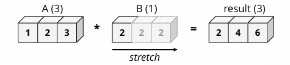

```python
A
```

```
array([1, 2, 3])
```

```python
B = 2
```

```python
A * B  # 가장 간단한 브로드 캐스팅 예
```

```
array([2, 4, 6])
```

##### 2) 브로드 캐스팅 규칙

- ‘연산의 두 배열에 대한 후미 축의 크기가 같거나 둘 중 하나가 1이어야 한다.’

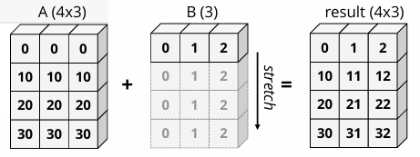

```python
A = np.array([[ 0, 0, 0],
              [10,10,10],
              [20,20,20],
              [30,30,30]])
```

```python
B = np.array([1,2,3])
```

```python
A + B
```

```
array([[ 1,  2,  3],
       [11, 12, 13],
       [21, 22, 23],
       [31, 32, 33]])
```

- 두 배열의 바깥 쪽(또는 다른 모든 바깥 쪽) 작업을 수행하는 편리한 방법을 제공함

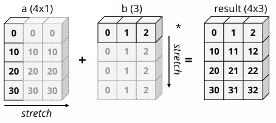

```python
A = np.array([0,10,20,30])
B = np.array([1,2,3])
```

```python
A[:, np.newaxis]
```

```
array([[ 0],
       [10],
       [20],
       [30]])
```

```python
B
```

```
array([1, 2, 3])
```

```python
A[:, np.newaxis] + B
```

```
array([[ 1,  2,  3],
       [11, 12, 13],
       [21, 22, 23],
       [31, 32, 33]])
```